# Public Health and Economic Impact of Severe Weather Events in the U.S.

Amade A.

November 22, 2015

## Synopsis

The goal of the paper is identification of extreme weather events which are:

1. most harmful with respect to pupulation health
2. causing the greatest negative economic consequences

in the United States and their dependent territories.

## Data processing

### Dataset overview and variable selection

Dataset for the analysis was based on the U.S. National Oceanic and Atmospheric Administration’s (NOAA) storm database.

The following commands have been used to load the dataset to a ‘storm’ data frame.

```r
stormDataFile <- "weather.rds"

if(!file.exists(stormDataFile)) {
    fileUrl <- "https://d396qusza40orc.cloudfront.net/repdata%2Fdata%2FStormData.csv.bz2"
    destFile <- "weather.csv.bz2"
    download.file(fileUrl, destfile = destFile, method = "curl")
    storm <- read.csv(destFile)
    saveRDS(storm,stormDataFile)
    }
storm <- readRDS(stormDataFile)
```

Dataset is downloaded from the source website only if id does not already exist in the working directory. Raw CSV files is read into R using read.csv() function and subsequently stored to RDS file for faster dataset load in future code runs.

The raw data set consist of 37 variables and 902,297 observations.

Variables which are not used in the analysis were removed from the dataset.

```r
library(plyr, warn.conflicts = FALSE) # 'plyr' package is used later in the analysis
library(dplyr, warn.conflicts = FALSE) # supress the messages on conflicst in variables
storm <- select(storm, -c(ZONENAMES, BGN_TIME, END_TIME, TIME_ZONE,
                                      STATE__, COUNTY, COUNTYNAME, BGN_RANGE,
                                      BGN_AZI, BGN_LOCATI, COUNTY_END, COUNTYENDN,
                                      END_RANGE, END_AZI, END_LOCATI, LENGTH,
                                      WIDTH, WFO, F, MAG, STATEOFFIC, STATE,
                                      LATITUDE, LONGITUDE, LATITUDE_E, LONGITUDE_)
                      )
```

### Variable cleanup and observation selection

#### Conversion of factor variables to character variables

For easier preprocessing, ‘purrr’ package has been used to convert factor to charater variables.

```r
library(purrr, warn.conflicts = FALSE) # supress the messages on conflicst in variables
storm %>% map_if(is.factor, as.character) -> storm
```

‘REMARKS’ variable has been stored in a separate data frame along with event’s reference number and removed from the main dataset for faster processing.

```r
remarks <- data.frame(REFNUM = storm$REFNUM,REMARKS = storm$REMARKS)
storm <- select(storm, -REMARKS)
```

#### Conversion of ‘date’ variables to ‘date’ type

Date variables (BGN_DATE and END_DATE) were processed using the ‘lubridate’ package.

```r
library(lubridate, warn.conflicts = FALSE)
storm <- storm %>% mutate(
    BGN_DATE = as.Date(mdy_hms(storm$BGN_DATE)),
    END_DATE = as.Date(mdy_hms(storm$END_DATE))
    )
```

The first event in the original dataset started on 1950-01-03 and last event finished on 2011-11-30.

```r
removedObsCount <- sum(year(storm$BGN_DATE) < 1996) # Count of the observations remoded
removedObsPerc <- (sum(year(storm$BGN_DATE) < 1996)/
                       nrow(storm))*100 # Percentage share of the observations removed
storm <- storm[!(storm$BGN_DATE < 1996),]
```

#### Rocoding variables measuring the monetary effects

Four variables measuring the magnitude of property (PROPDMG, PROPDMGEXP) and crop damages (CROPDMG, CROPDMGEXP) have been recoded into two variables - PROPDMG and CROPDMG. In order to do that, variables PROPDMGEXP and CROPDMGEXP have been cleaned up from values different than “K”, “M” and “B” (ignoring case) and recoded to their numeric equivalents (representing thousands, millions and billions respectively). In the next step PROPDMG and CROPDMG variables have been multiplied by them.

```r
storm <- mutate(storm, PROPDMGEXP = toupper(PROPDMGEXP), CROPDMGEXP = toupper(CROPDMGEXP))
storm$PROPDMGEXP[!(storm$PROPDMGEXP %in% c("K", "M", "B"))] <- 1
storm$CROPDMGEXP[!(storm$CROPDMGEXP %in% c("K", "M", "B"))] <- 1

storm$PROPDMGEXP <- as.numeric(mapvalues(
    storm$PROPDMGEXP, from = c("K", "M", "B"), to = c(1000,1000000,1000000000)))
storm$CROPDMGEXP <- as.numeric(mapvalues(
    storm$CROPDMGEXP, from = c("K", "M", "B"), to = c(1000,1000000,1000000000)))

storm$PROPDMG <- (storm$PROPDMG * storm$PROPDMGEXP)
storm$CROPDMG <- (storm$CROPDMG * storm$CROPDMGEXP)

storm <- select(storm, -c(PROPDMGEXP, CROPDMGEXP))

options(scipen=999) # disable scientific notation
```

#### Recoding variables describing the event type

```r
length(unique(storm$EVTYPE))
```

```
## [1] 985
```

After conversion of all values of *EVTYPE* variable to upper case, number of unique event types decreased to 898

```r
storm$EVTYPE <- toupper(storm$EVTYPE)
length(unique(storm$EVTYPE))
```

```
## [1] 898
```

In the next processing step, event descriptions in the *EVTYPE* variable have been mapped to all 48 event types specified in the [NWS Directive 10-1605](http://www.ncdc.noaa.gov/stormevents/pd01016005curr.pdf) using the ‘gsub’ function. Oservations with event descriptions which could not been matched to an appropriate event have been removed from the dataset.

```r
storm$EVTYPE <- gsub("TSTM","THUNDERSTORM",storm$EVTYPE, ignore.case = TRUE)
storm$EVTYPE <- gsub("FLD","FLOOD",storm$EVTYPE, ignore.case = TRUE)

rowsBeforeEventCleanup <- nrow(storm)
# Astronomical Low Tide
storm$EVTYPE <- gsub(".*Astronomical Low Tide.*","Astronomical Low Tide",storm$EVTYPE, ignore.case = TRUE)
# Avalanche
storm$EVTYPE <- gsub(".*Avalanche.*","Avalanche",storm$EVTYPE, ignore.case = TRUE)
storm$EVTYPE <- gsub(".*Avalance.*","Avalanche",storm$EVTYPE, ignore.case = TRUE)
# Blizzard
storm$EVTYPE <- gsub(".*Blizzard.*","Blizzard",storm$EVTYPE, ignore.case = TRUE)
#Coastal Flood
storm$EVTYPE <- gsub(".*Coastal Flood.*","Coastal Flood",storm$EVTYPE, ignore.case = TRUE)
#Cold/Wind Chill
storm$EVTYPE <- gsub(".*Cold/Wind Chill.*","Cold/Wind Chill",storm$EVTYPE, ignore.case = TRUE)
storm$EVTYPE <- gsub("^Cold$","Cold/Wind Chill",storm$EVTYPE, ignore.case = TRUE)
#Debris Flow
storm$EVTYPE <- gsub(".*Debris Flow.*","Debris Flow",storm$EVTYPE, ignore.case = TRUE)
#Dense Fog
storm$EVTYPE <- gsub(".*Dense Fog.*","Dense Fog",storm$EVTYPE, ignore.case = TRUE)
#Dense Smoke
storm$EVTYPE <- gsub(".*Dense Smoke.*","Dense Smoke",storm$EVTYPE, ignore.case = TRUE)
#Drought
storm$EVTYPE <- gsub(".*Drought.*","Drought",storm$EVTYPE, ignore.case = TRUE)
#Dust Devil
storm$EVTYPE <- gsub(".*Dust Devil.*","Dust Devil",storm$EVTYPE, ignore.case = TRUE)
#Dust Storm
storm$EVTYPE <- gsub(".*Dust Storm.*","Dust Storm",storm$EVTYPE, ignore.case = TRUE)
#Excessive Heat
storm$EVTYPE <- gsub(".*Excessive Heat.*","Excessive Heat",storm$EVTYPE, ignore.case = TRUE)
storm$EVTYPE <- gsub(".*Record Heat.*","Excessive Heat",storm$EVTYPE, ignore.case = TRUE)
#Extreme Cold/Wind Chill
storm$EVTYPE <- gsub(".*Extreme.*Cold*","Extreme Cold/Wind Chill",storm$EVTYPE, ignore.case = TRUE)
storm$EVTYPE <- gsub(".*Extreme.*Wind.*Chill.*","Extreme Cold/Wind Chill",storm$EVTYPE, ignore.case = TRUE)
#Flash Flood
storm$EVTYPE <- gsub(".*Flash Flood.*","Flash Flood",storm$EVTYPE, ignore.case = TRUE)
#Flood
storm$EVTYPE <- gsub("^Flood.*","Flood",storm$EVTYPE, ignore.case = TRUE)
storm$EVTYPE <- gsub(".*Urban.*Flood.*","Flood",storm$EVTYPE, ignore.case = TRUE)
#Freezing Fog
storm$EVTYPE <- gsub(".*Freezing Fog.*","Freezing Fog",storm$EVTYPE, ignore.case = TRUE)
#Frost/Freeze
storm$EVTYPE <- gsub(".*Frost.*Freeze.*","Frost/Freeze",storm$EVTYPE, ignore.case = TRUE)
#Funnel Cloud
storm$EVTYPE <- gsub(".*Funnel.*","Funnel Cloud",storm$EVTYPE, ignore.case = TRUE)
#Hail
storm$EVTYPE <- gsub("^Hail.*","Hail",storm$EVTYPE, ignore.case = TRUE)
#Heat
storm$EVTYPE <- gsub("^Heat.*","Heat",storm$EVTYPE, ignore.case = TRUE)
storm$EVTYPE <- gsub(".*Warm.*","Heat",storm$EVTYPE, ignore.case = TRUE)
#Heavy Rain
storm$EVTYPE <- gsub("*Heavy Rain.*","Heavy Rain",storm$EVTYPE, ignore.case = TRUE)
#Heavy Snow
storm$EVTYPE <- gsub(".*Heavy Snow.*","Heavy Snow",storm$EVTYPE, ignore.case = TRUE)
#High Surf
storm$EVTYPE <- gsub(".*High Surf.*","High Surf",storm$EVTYPE, ignore.case = TRUE)
#High Wind
storm$EVTYPE <- gsub("^High Wind.*","High Wind",storm$EVTYPE, ignore.case = TRUE)
#Hurricane (Typhoon)
storm$EVTYPE <- gsub(".*Hurricane.*","Hurricane",storm$EVTYPE, ignore.case = TRUE)
storm$EVTYPE <- gsub(".*Typhoon.*","Hurricane",storm$EVTYPE, ignore.case = TRUE)
#Ice Storm
storm$EVTYPE <- gsub(".*Ice Storm.*","Ice Storm",storm$EVTYPE, ignore.case = TRUE)
#Lake-Effect Snow"
storm$EVTYPE <- gsub(".*Lake.Effect Snow.*","Lake-Effect Snow",storm$EVTYPE, ignore.case = TRUE)
#Lakeshore Flood
storm$EVTYPE <- gsub(".*Lakeshore Flood.*","Lakeshore Flood",storm$EVTYPE, ignore.case = TRUE)
#Lightning
storm$EVTYPE <- gsub(".*Lightning.*","Lightning",storm$EVTYPE, ignore.case = TRUE)
#Marine Hail
storm$EVTYPE <- gsub(".*Marine Hail.*","Marine Hail",storm$EVTYPE, ignore.case = TRUE)
#Marine High Wind
storm$EVTYPE <- gsub(".*Marine High Wind.*","Marine High Wind",storm$EVTYPE, ignore.case = TRUE)
#Marine Strong Wind
storm$EVTYPE <- gsub(".*Marine Strong Wind.*","Marine Strong Wind",storm$EVTYPE, ignore.case = TRUE)
#Marine Thunderstorm Wind
storm$EVTYPE <- gsub(".*Marine Thunderstorm Wind.*","Marine Thunderstorm Wind",storm$EVTYPE, ignore.case = TRUE)
#Rip Current
storm$EVTYPE <- gsub(".*Rip Current.*","Rip Current",storm$EVTYPE, ignore.case = TRUE)
#Seiche
storm$EVTYPE <- gsub(".*Seiche.*","Seiche",storm$EVTYPE, ignore.case = TRUE)
#Sleet
storm$EVTYPE <- gsub(".*Sleet.*","Sleet",storm$EVTYPE, ignore.case = TRUE)
#Sneakerwave
storm$EVTYPE <- gsub(".*Sneakerwave.*","Sneakerwave",storm$EVTYPE, ignore.case = TRUE)
#Storm Surge/Tide
storm$EVTYPE <- gsub(".*Storm Surge/Tide.*","Storm Surge/Tide",storm$EVTYPE, ignore.case = TRUE)
#Strong Wind
storm$EVTYPE <- gsub("^Strong Wind.*","Strong Wind",storm$EVTYPE, ignore.case = TRUE)
#Thunderstorm Wind
storm$EVTYPE <- gsub("^Thunderstorm Wind.*","Thunderstorm Wind",storm$EVTYPE, ignore.case = TRUE)
#Tornado
storm$EVTYPE <- gsub(".*Tornado.*","Tornado",storm$EVTYPE, ignore.case = TRUE)
#Tropical Depression
storm$EVTYPE <- gsub(".*Tropical Depression.*","Tropical Depression",storm$EVTYPE, ignore.case = TRUE)
#Tropical Storm
storm$EVTYPE <- gsub(".*Tropical Storm.*","Tropical Storm",storm$EVTYPE, ignore.case = TRUE)
#Tsunami
storm$EVTYPE <- gsub(".*Tsunami.*","Tsunami",storm$EVTYPE, ignore.case = TRUE)
#Volcanic Ash
storm$EVTYPE <- gsub(".*Volcanic Ash.*","Volcanic Ash",storm$EVTYPE, ignore.case = TRUE)
#Waterspout
storm$EVTYPE <- gsub(".*Waterspout.*","Waterspout",storm$EVTYPE, ignore.case = TRUE)
#Wildfire
storm$EVTYPE <- gsub(".*Wildfire.*","Wildfire",storm$EVTYPE, ignore.case = TRUE)
#Winter Storm"
storm$EVTYPE <- gsub("*Winter Storm*","Winter Storm",storm$EVTYPE, ignore.case = TRUE)
#Winter Weather"
storm$EVTYPE <- gsub(".*Winter Weather.*","Winter Weather",storm$EVTYPE, ignore.case = TRUE)

# Convert event desctiptions to upper case

storm$EVTYPE <- toupper(storm$EVTYPE)

# Store all event descriptions to event variable

events <- toupper(c("Astronomical Low Tide", "Avalanche", "Blizzard", "Coastal Flood", "Cold/Wind Chill", "Debris Flow", "Dense Fog", "Dense Smoke", "Drought", "Dust Devil", "Dust Storm", "Excessive Heat", "Extreme Cold/Wind Chill", "Flash Flood", "Flood", "Freezing Fog", "Frost/Freeze", "Funnel Cloud", "Hail", "Heat", "Heavy Rain", "Heavy Snow", "High Surf", "High Wind", "Hurricane", "Ice Storm", "Lake-Effect Snow", "Lakeshore Flood", "Lightning", "Marine Hail", "Marine High Wind", "Marine Strong Wind", "Marine Thunderstorm Wind", "Rip Current", "Seiche", "Sleet", "Sneakerwave", "Storm Surge/Tide", "Strong Wind", "Thunderstorm Wind", "Tornado", "Tropical Depression", "Tropical Storm", "Tsunami", "Volcanic Ash", "Waterspout","Wildfire", "Winter Storm", "Winter Weather"))
removedInEventCleanup <- length(storm$EVTYPE[!(storm$EVTYPE %in% events)])

# Remove observations referring to weather events not specified in the NWS Directive 10-1605

storm <- storm[(storm$EVTYPE %in% events),]

removedInEventCleanupPercentage <- (removedInEventCleanup/rowsBeforeEventCleanup)*100
removedInEventCleanupPercentage
```

```
## [1] 0.8581795
```

Ultimately, 0.9 % of the observations in the analyzed epriod have been excluded from the dataset as a result of *EVTYPE* variable cleanup.

### Tidy Dataset variable description

Variables:

- *BGN_DATE* - represents the date when the event started
- *EVTYPE* - one of the 48 severe weather event types
- *FATALITIES* - deaths caused by the weather event
- *INJURIES* - injuries caused by the weather event
- *PROPDMG* - property damage caused by the weather event (in USD)
- *CROPDMG* - crop damage caused by the weather event (in USD)
- *REFNUM* - identification number of the individual weather event

## Data analysis

### Dataset summary

```r
tidyDatasetRow <- nrow(storm)
tidyDatasetCol <- ncol(storm)
```

The tidy dataset has 8 variables across 836,984 observations.

10 most frequent weather events along with their shares are presented in the table below.

```r
storm %>% group_by(EVTYPE) %>% dplyr::summarize(count = length(EVTYPE), share = length(EVTYPE)/length(storm$EVTYPE)) %>% dplyr::arrange(desc(count)) %>% as.data.frame() %>% head(10)
```

```
##                      EVTYPE  count      share
## 1         THUNDERSTORM WIND 300674 0.35923506
## 2                      HAIL 272599 0.32569201
## 3               FLASH FLOOD  55668 0.06651023
## 4                   TORNADO  42786 0.05111926
## 5                     FLOOD  29284 0.03498753
## 6                 HIGH WIND  21786 0.02602917
## 7                HEAVY SNOW  15795 0.01887133
## 8                 LIGHTNING  15775 0.01884743
## 9  MARINE THUNDERSTORM WIND  11987 0.01432166
## 10               HEAVY RAIN  11799 0.01409704
```

```r
globalDeathCount <- sum(storm$FATALITIES)
globalInjuriesCount <- sum(storm$INJURIES)
globalPropertyDamage <- sum(storm$PROPDMG)
globalCropDamage <- sum(storm$CROPDMG)
```

### Outlier detection

The following 4 tables each present 10 individual weather events with the most significant impact along with their reference numbers, which can be used to identify their narratives stored in the ‘remarks’ data frame.

```r
deathTop10Events <- storm %>% select(BGN_DATE, EVTYPE, FATALITIES, REFNUM) %>% dplyr::arrange(desc(FATALITIES)) %>% as.data.frame() %>% head(10)

injuryTop10Events <- storm %>% select(BGN_DATE, EVTYPE, INJURIES, REFNUM) %>% dplyr::arrange(desc(INJURIES)) %>% as.data.frame() %>% head(10)

propDmgTop10Events <- storm %>% select(BGN_DATE, EVTYPE, PROPDMG, REFNUM) %>% dplyr::arrange(desc(PROPDMG)) %>% as.data.frame() %>% head(10)

cropDmgTop10Events <- storm %>% select(BGN_DATE, EVTYPE, CROPDMG, REFNUM) %>% dplyr::arrange(desc(CROPDMG)) %>% as.data.frame() %>% head(10)

deathTop10Events
```

```
##      BGN_DATE         EVTYPE FATALITIES REFNUM
## 1  1995-07-12           HEAT        583 198690
## 2  2011-05-22        TORNADO        158 862563
## 3  1999-07-28 EXCESSIVE HEAT         99 355098
## 4  1999-07-04 EXCESSIVE HEAT         74 371072
## 5  1995-07-01 EXCESSIVE HEAT         67 230914
## 6  2005-09-21 EXCESSIVE HEAT         49 598470
## 7  2006-07-16 EXCESSIVE HEAT         46 606292
## 8  2011-04-27        TORNADO         44 860355
## 9  1979-04-10        TORNADO         42 157885
## 10 1999-07-18 EXCESSIVE HEAT         42 362806
```

```r
injuryTop10Events
```

```
##      BGN_DATE    EVTYPE INJURIES REFNUM
## 1  1979-04-10   TORNADO     1700 157885
## 2  1994-02-08 ICE STORM     1568 223436
## 3  2011-05-22   TORNADO     1150 862563
## 4  1998-10-17     FLOOD      800 344098
## 5  2011-04-27   TORNADO      800 860355
## 6  2004-08-13 HURRICANE      780 529299
## 7  1998-10-17     FLOOD      750 344117
## 8  2011-04-27   TORNADO      700 858208
## 9  1998-10-17     FLOOD      600 344097
## 10 1998-10-17     FLOOD      550 344102
```

```r
propDmgTop10Events
```

```
##      BGN_DATE         EVTYPE      PROPDMG REFNUM
## 1  2006-01-01          FLOOD 115000000000 605943
## 2  2005-08-28      HURRICANE  16930000000 577615
## 3  2005-10-24      HURRICANE  10000000000 569288
## 4  2005-08-28      HURRICANE   7350000000 581533
## 5  2005-08-29      HURRICANE   5880000000 581537
## 6  2004-08-13      HURRICANE   5420000000 529299
## 7  2001-06-05 TROPICAL STORM   5150000000 444407
## 8  1993-03-12   WINTER STORM   5000000000 187564
## 9  2004-09-04      HURRICANE   4830000000 529384
## 10 2004-09-13      HURRICANE   4000000000 529446
```

```r
cropDmgTop10Events
```

```
##      BGN_DATE                  EVTYPE    CROPDMG REFNUM
## 1  1994-02-09               ICE STORM 5000000000 211887
## 2  2005-08-29               HURRICANE 1510000000 581537
## 3  2006-01-01                 DROUGHT 1000000000 639314
## 4  1998-12-20 EXTREME COLD/WIND CHILL  596000000 312976
## 5  2001-08-01                 DROUGHT  578850000 422598
## 6  2000-11-01                 DROUGHT  515000000 410125
## 7  1995-08-01                 DROUGHT  500000000 201230
## 8  1998-07-06                 DROUGHT  500000000 336988
## 9  1999-09-15               HURRICANE  500000000 366653
## 10 1999-07-01                 DROUGHT  500000000 371057
```

As can be seen in the ‘propDmgTop10Events’ table, two events with reference numbers 605943 and 577615 show extronardily high property damages of $115bln and $17bln. In order to determine whether those values were recorded correctly, the descriptions of the events have been investigated.  
Event 577615 refers to Hurricane Katrina, which justifies the recorded property damages. Property damages figure for the event 605943 however seems out of range based on the following event narrative:

```r
remarks[remarks$REFNUM == 605943,2]
```

```
## [1] Major flooding continued into the early hours of January 1st, before the Napa River finally fell below flood stage and the water receeded. Flooding was severe in Downtown Napa from the Napa Creek and the City and Parks Department was hit with $6 million in damage alone. The City of Napa had 6…
## 436781 Levels:                                       \n   \n   \n  ... Zones 22 and 23 were added to the high wind warning of  January 26. Peak winds Sitka 55MPH, Cape Decision 58MPH, and Cape Spencer 64MPH.\n
```

As a result, in order to improve the data quality, property damages value for that event has been changed to 76mln (amount mentioned in the narrative).

```r
storm$PROPDMG[storm$REFNUM == 605943] <- 76000000
```

## Results

### Measuring public health impact

Measurment of a public health impact has been limited to measuring number of injuries and deaths related to a particular weather event.

Graphs below show 10 types of severe weather events in terms of total number of deaths and injuries caused by them in the analyzed period.

```r
deathTop10EventTypes <- storm %>% group_by(EVTYPE) %>% dplyr::summarize(FATALITIES = sum(FATALITIES)) %>%  dplyr::arrange(desc(FATALITIES)) %>% as.data.frame() %>% head(10)

injuryTop10EventTypes <- storm %>% group_by(EVTYPE) %>% dplyr::summarize(INJURIES = sum(INJURIES)) %>%  dplyr::arrange(desc(INJURIES)) %>% as.data.frame() %>% head(10)

deathOtherEventTypes <- storm %>% group_by(EVTYPE) %>% dplyr::summarize(FATALITIES = sum(FATALITIES)) %>%  dplyr::arrange(desc(FATALITIES)) %>% as.data.frame() %>% tail(length(unique(storm$EVTYPE))-10)

injuryOtherEventTypes <- storm %>% group_by(EVTYPE) %>% dplyr::summarize(INJURIES = sum(INJURIES)) %>%  dplyr::arrange(desc(INJURIES)) %>% as.data.frame() %>% tail(length(unique(storm$EVTYPE))-10)

fatalitiesSummary <- rbind(
    deathTop10EventTypes,
    c("OTHER", sum(deathOtherEventTypes$FATALITIES))
    )
injuriesSummary <- rbind(
    injuryTop10EventTypes,
    c("OTHER", sum(injuryOtherEventTypes$INJURIES))
    )
```

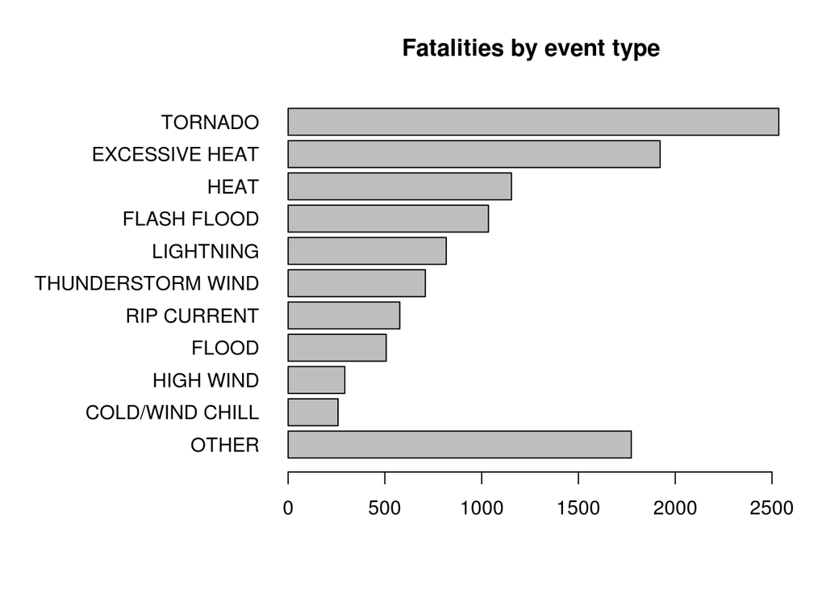

```r
par(mar=c(5,12,4,2))
barplot(as.numeric(fatalitiesSummary$FATALITIES[11:1]), main="Fatalities by event type", horiz=TRUE, names.arg=fatalitiesSummary$EVTYPE[11:1], las = 1)
```

Based on the graph above, the most deadly severe weather event type in the analyzed period was TORNADO which caused 2,535 deaths (21.9 % of all deaths).

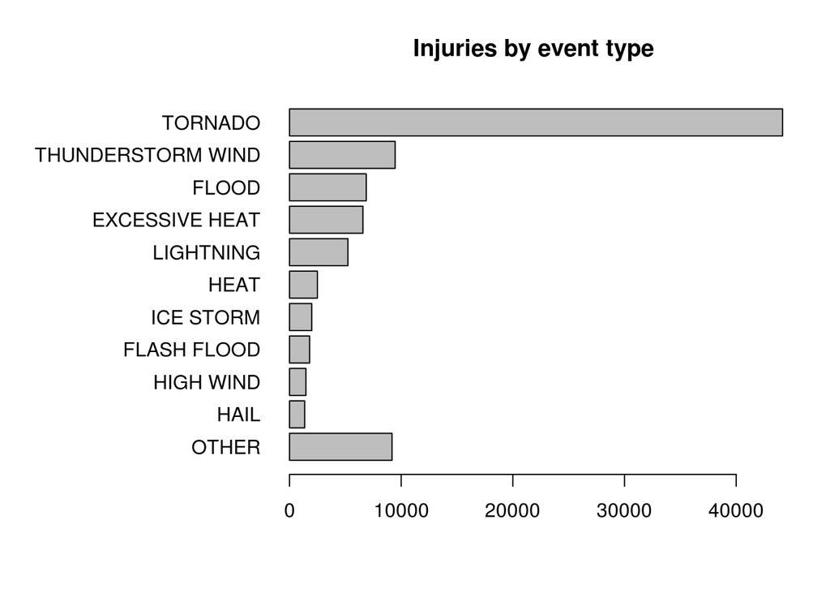

```r
par(mar=c(5,12,4,2))
barplot(as.numeric(injuriesSummary$INJURIES[11:1]), main="Injuries by event type", horiz=TRUE, names.arg=injuriesSummary$EVTYPE[11:1], las = 1)
```

In terms of injuries, the event type with the strongest impact was also TORNADO causing 44,153 injuries (48.7 % of all injuries).

Summarizing the information from the two charts above, TORNADOES were the events causing the most negative population health impact.

### Measuring economic impact

Measurment of an economic impact of a particular event has been limited to measuring crop and property damages in dollar terms.

```r
econImpTop10EventTypes <- storm %>% group_by(EVTYPE) %>% dplyr::summarize(ECONIMPACT = sum(PROPDMG) + sum(CROPDMG)) %>%  dplyr::arrange(desc(ECONIMPACT)) %>% as.data.frame() %>% head(10)

econImpOtherEventTypes <- storm %>% group_by(EVTYPE) %>% dplyr::summarize(ECONIMPACT = sum(PROPDMG) + sum(CROPDMG)) %>%  dplyr::arrange(desc(ECONIMPACT)) %>% as.data.frame() %>% tail(length(unique(storm$EVTYPE))-10)

econImpactSummary <- rbind(
    econImpTop10EventTypes,
    c("OTHER", sum(econImpOtherEventTypes$ECONIMPACT))
    )
```

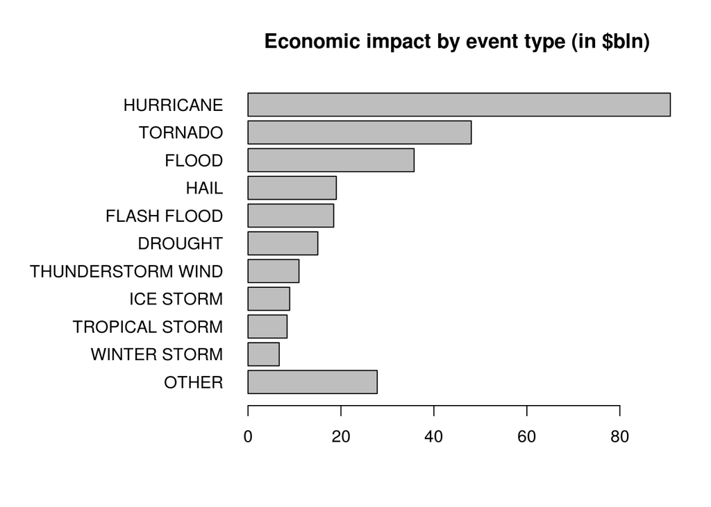

```r
par(mar=c(5,12,4,2))
barplot(as.numeric(econImpactSummary$ECONIMPACT[11:1])/10^9, main="Economic impact by event type (in $bln)", horiz=TRUE, names.arg=econImpactSummary$EVTYPE[11:1], las = 1)
```

Based on the graph above, the severe weather event type with the highest negative economic impact was HURRICANE, resulting in $90.9bln property and economic damages in the analyzed period (31.3 % of all damages).